# Changde Cheng

2012

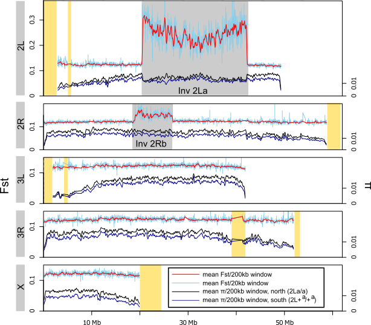

5. Changde Cheng, White BJ, Kamdem C, Mockaitis K, Costantini C, Hahn MW, Besansky NJ.  
**Ecological genomics of Anopheles gambiae along a latitudinal cline: a population-resequencing approach**  
[Genetics.](https://www.ncbi.nlm.nih.gov/pubmed/22209907/) 2012 Apr;190(4):1417-32.

🍄🍄

2011

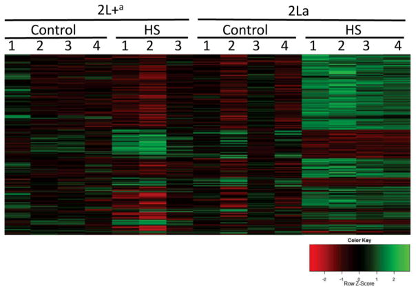

4. Cassone BJ, Molloy MJ, Changde Cheng, Tan JC, Hahn MW, Besansky NJ.  
**Divergent transcriptional response to thermal stress by Anopheles gambiae larvae carrying alternative arrangements of inversion 2La**  
[Mol Ecol.](https://www.ncbi.nlm.nih.gov/pubmed/21535279/) 2011 Jun;20(12):2567-80.

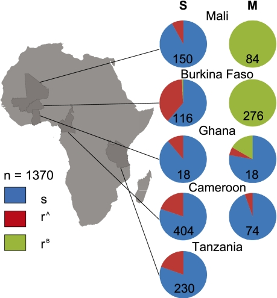

3. White BJ, Lawniczak MK, Changde Cheng, Coulibaly MB, Wilson MD, Sagnon N, Costantini C, Simard F, Christophides GK, Besansky NJ.  
**Adaptive divergence between incipient species of Anopheles gambiae increases resistance to Plasmodium**  
[Proc Natl Acad Sci U S A.](https://www.ncbi.nlm.nih.gov/pubmed/21173248/) 2011 Jan 4;108(1):244-9.

🍄

2010

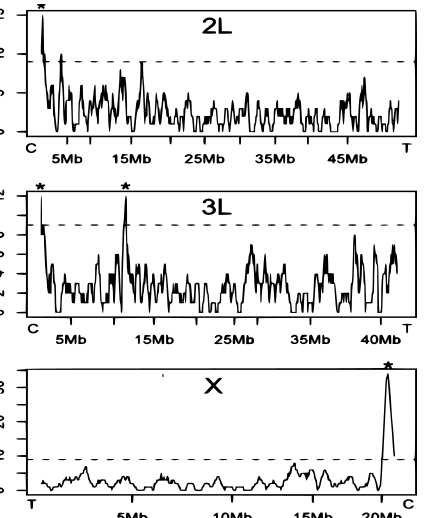

2. White BJ, Changde Cheng, Simard F, Costantini C, Besansky NJ.  
**Genetic association of physically unlinked islands of genomic divergence in incipient species of Anopheles gambiae**  
[Mol Ecol.](https://www.ncbi.nlm.nih.gov/pubmed/20149091/) 2010 Mar;19(5):925-39.

🍄

2009

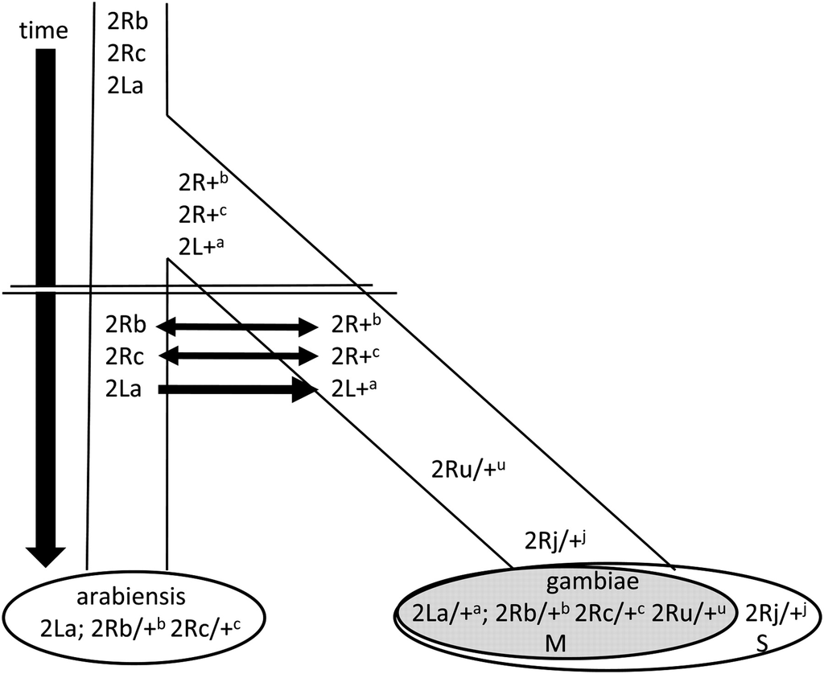

1. White BJ, Changde Cheng, Sangaré D, Lobo NF, Collins FH, Besansky NJ.  
**The population genomics of trans-specific inversion polymorphisms in Anopheles gambiae**  
[Genetics.](https://www.ncbi.nlm.nih.gov/pubmed/19581444/) 2009 Sep;183(1):275-88.

${\ast}$: Co-first author

${\dagger}$: Co-corresponding author